# Session 1 — Know Your Data, Choose Your Test

Variable types · describing data · checking it · choosing a test · reading a result · Lab 1

Community Medicine Workshop

## Where we are

- The **Basic** track showed *which* test to run and *how* to run it in R
- This workshop adds the two things a thesis examiner asks about:
  - **Were the assumptions met?** How did you check, and what did you do if not?
  - **What does the result mean?** In words, with an effect size and a confidence interval
- By the end of today you can:
  - classify variables and describe them correctly
  - **check the data** before testing anything
  - choose a test from four questions
  - read a p-value, a confidence interval and an effect size

## Our data

- **631 adults** screened for NCDs (`data/prac_modded.xlsx`, the practice dataset of the Basic track)
- Sex, age, wealth index, marital status, poverty line
- Screening history, past hypertension and diabetes
- Blood pressure, glucose, height, weight
- Foot pain **before and after** an intervention
- Fasting glucose and SBP at **presentation, 3 and 6 months**

```r
p |> select(sex_of_participants, age_of_participants,
            wealth_index_of_participants, sbp_in_mm_hg) |>
  head(5)
```

```
# A tibble: 5 × 4
  sex_of_participants age_of_participants wealth_index_of_partici…¹ sbp_in_mm_hg
  <fct>                             <dbl> <fct>                            <dbl>
1 male                                 51 middle                             135
2 female                               45 middle                             158
3 female                               43 middle                             105
4 female                               48 richer                             142
5 male                                 36 richest                            148
# ℹ abbreviated name: ¹wealth_index_of_participants
```

# Topic 1 — What kind of variable?

## Four kinds of variable

| Type | What it is | In our data |
| --- | --- | --- |
| **Nominal** | categories, no order | sex, marital status, diabetes yes/no |
| **Ordinal** | categories **with order**, gaps not equal | wealth index (poorest → richest) |
| **Interval** | numbers, equal gaps, **no true zero** | temperature in °C (not in our data) |
| **Ratio** | numbers, equal gaps, **true zero** | age, weight, SBP, glucose |

The **outcome’s type** decides the family of tests: counts and percentages for categories; means or medians for numbers.

## Describing a category: counts and percentages

```r
p |> count(wealth_index_of_participants) |>
  mutate(percent = round(100 * n / sum(n), 1))
```

```
# A tibble: 5 × 3
  wealth_index_of_participants     n percent
  <fct>                        <int>   <dbl>
1 poorest                         76    12
2 poorer                         113    17.9
3 middle                         139    22
4 richer                         158    25
5 richest                        145    23
```

- Give the **order** for ordinal variables (`factor(..., levels = ...)`), or R sorts them alphabetically
- Always report **n and %**, and the denominator if anything is missing

## Describing a number: mean or median?

```r
p |> summarise(mean = mean(age_of_participants), sd = sd(age_of_participants),
               median = median(age_of_participants),
               q1 = quantile(age_of_participants, .25),
               q3 = quantile(age_of_participants, .75))
```

```
# A tibble: 1 × 5
   mean    sd median    q1    q3
  <dbl> <dbl>  <dbl> <dbl> <dbl>
1  43.4  11.5     42    35    51
```

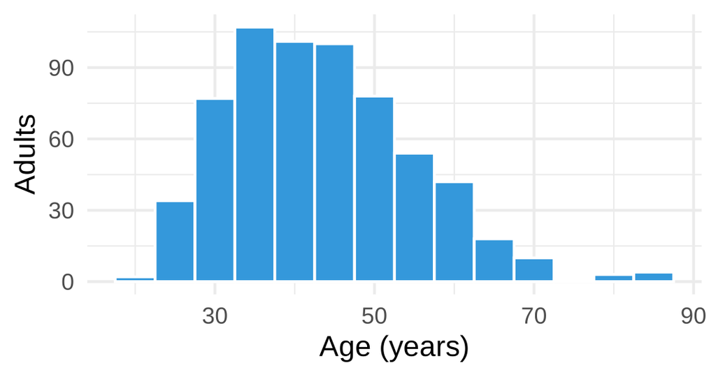

```r
ggplot(p, aes(age_of_participants)) +
  geom_histogram(binwidth = 5, fill = col_blue, colour = "white") +
  labs(x = "Age (years)", y = "Adults")
```

**Symmetric** → mean (SD); **skewed** or outliers → median (IQR). Age is a little right-skewed: mean 43.4 > median 42.

# Topic 2 — Check before you test

## A test cannot rescue bad data

```r
p_raw |> summarise(sbp_below_dbp = sum(sbp_in_mm_hg < dbp_in_mm_hg),
                   min_weight = min(weight), min_height = min(height),
                   max_glucose = max(glucose_level_mg_d_l))
```

```
# A tibble: 1 × 4
  sbp_below_dbp min_weight min_height max_glucose
          <int>      <dbl>      <dbl>       <dbl>
1             4        5.6       135.         291
```

```r
p_raw |> filter(sbp_in_mm_hg < dbp_in_mm_hg | weight < 20) |>
  select(s_no, sbp_in_mm_hg, dbp_in_mm_hg, height, weight)
```

```
# A tibble: 5 × 5
   s_no sbp_in_mm_hg dbp_in_mm_hg height weight
  <dbl>        <dbl>        <dbl>  <dbl>  <dbl>
1    57           70          125   168.   47.8
2   212           71          119   161.   35.7
3   301          102           61   161     5.6
4   388           78          143   160.   53.6
5   540           62           88   163    53.5
```

In 4 adults the systolic pressure is **lower** than the diastolic (the two columns were swapped at entry), and one adult of 161 cm weighs 5.6 kg (the decimal point was lost: 56 kg). These are recording problems, not biology. A glucose of 291 mg/dL, by contrast, is high but **possible** in uncontrolled diabetes: keep it.

## What to do with suspicious values

1. **Look** at every variable first: `summary()`, a histogram, impossible combinations (SBP < DBP)
2. **Query** the source (case sheet, register) and correct what can be corrected
3. Decide **before** testing what you exclude, and **report it** (“4 records with SBP and DBP swapped were corrected from the case sheets”)
4. Run the analysis **with and without** the doubtful records: a **sensitivity analysis**

In this workshop the case sheets confirmed both errors, so they are **corrected** (Lab 1 does it). Every later session uses the corrected data. **Extreme but possible** values are not errors: they stay.

# Topic 3 — Choosing a test

## Four questions choose the test

1. **What is the outcome?** Category (yes/no, groups) or number (mmHg, kg)?
2. **How many groups** am I comparing? One (against a known value), two, or more?
3. **Paired or independent?** Same people measured twice (before/after), or different people?
4. **Do the assumptions hold?** Roughly normal, similar spread, enough expected counts?

Questions 1–3 come from the **study design** and are fixed before you see the data. Only question 4 is checked on the data (Session 2).

## The map: category outcome

| Comparison | Independent groups | Paired (same people) |
| --- | --- | --- |
| One group vs expected proportions | **Chi-square goodness of fit** | — |
| 2 × 2 table | **Chi-square**; **Fisher’s exact** if an expected count < 5 | **McNemar** (exact McNemar if few discordant pairs) |
| Larger table (r × c) | **Chi-square** if ≥ 80% of expected counts ≥ 5 and none < 1; else **Monte Carlo** or **Fisher** | — |
| Several predictors at once | **Logistic regression** (Regression track) | — |

## The map: number outcome

| Comparison | Roughly normal | Skewed, ordinal or outliers |
| --- | --- | --- |
| One group vs a known value | **one-sample t** | **one-sample Wilcoxon** |
| Two independent groups | **Welch t** | **Mann–Whitney U** |
| Two paired measurements | **paired t** | **Wilcoxon signed-rank** |
| ≥ 3 independent groups | **one-way ANOVA** (Welch ANOVA if spreads differ) | **Kruskal–Wallis** |
| ≥ 3 repeated measurements | **repeated-measures ANOVA** | **Friedman** |
| Two numbers together | **Pearson r** | **Spearman ρ** |

# Topic 4 — Reading a result

## Three numbers, not one

- **Effect size**: *how big* is the difference? (difference in means, odds ratio, Cohen’s d, r)
- **95% confidence interval**: the range of effect sizes compatible with the data
- **p-value**: *if there were truly no difference*, how often would data at least this extreme turn up by chance?

A p-value is **not** the probability that the null hypothesis is true, and it says **nothing about size or importance**. p > 0.05 is **not** proof of no difference.

## Example: weight in women and men

```r
t.test(weight ~ sex_of_participants, data = p)
```

```
    Welch Two Sample t-test

data:  weight by sex_of_participants
t = -7.7292, df = 558.87, p-value = 5.057e-14
alternative hypothesis: true difference in means between group female and group male is not equal to 0
95 percent confidence interval:
 -8.754184 -5.206381
sample estimates:
mean in group female   mean in group male
            57.31701             64.29730
```

## The sentence to write

“Mean weight was 64.3 kg in men and 57.3 kg in women (difference 7.0 kg, 95% CI 5.2 to 8.8; Welch t-test, p < 0.001; Cohen’s d = 0.63).”

- R reports **women − men** (alphabetical order), a negative number: turn it round so the sentence reads naturally
- Men are heavier by **5.2 to 8.8 kg**: the CI gives the size, not only “significant”
- d = 0.63 is a **medium** difference (rough guide: 0.2 small, 0.5 medium, 0.8 large). Men are also taller: weight differs partly *because* height does (BMI, Session 5)
- Had p been above 0.05: “no evidence of a difference”, **never** “the groups are the same”

## 🔧 Switch to R — Lab 1

**File:** `stats-workshop/labs/lab1_describe.R`

- counts and percentages, with the wealth index in order
- mean (SD) and median (IQR), and which to report
- impossible and suspicious values, and how many
- choosing the test for five research questions

**Time:** 30 minutes · answer the Q questions in the comments

## Self-check quiz (1/5)

The wealth index (poorest, poorer, middle, richer, richest) is which kind of variable?

- Nominal, because its levels are labels with no order
- Ordinal, because its levels have an order but unequal gaps
- Interval, because each level is exactly one equal step apart
- Ratio, because the poorest level is a true zero point

## Self-check quiz (2/5)

Fasting glucose is strongly right-skewed with a few very high values. How should you summarise it?

- Mean and standard deviation, because it is a number
- Median and interquartile range, because it is skewed
- Mode and range, because the high values are outliers
- Mean and standard error, because the sample is large

## Self-check quiz (3/5)

You find 4 records where systolic pressure is lower than diastolic. What should you do first?

- Run the planned test, because a large sample absorbs a few errors
- Delete those rows quietly so the results look cleaner
- Query the source records, then decide and report what to exclude
- Swap the two columns for those rows and carry on testing

## Self-check quiz (4/5)

Foot pain (yes/no) was recorded in the same adults before and after an intervention. Which test compares the two?

- Chi-square test of independence on the before-after 2 x 2 table
- Fisher’s exact test, because the outcome has only two levels
- Paired t-test on the yes/no answers coded as 0 and 1
- McNemar test, because the same people were measured twice

## Self-check quiz (5/5)

A comparison gives p = 0.54 with a 95% CI for the difference of -1.7 to 3.2 kg. What is the right reading?

- No evidence of a difference; a large difference is unlikely
- The two groups have been shown to have the same mean weight
- There is a 54% chance that the null hypothesis is really true
- The study failed, so the result should not be reported

## Score and take-home

**Your score:**

- The **outcome type**, the **number of groups** and **pairing** come from the design
- **Describe** before you test: n (%), mean (SD) or median (IQR)
- **Check** for impossible values; report what you excluded
- Report **effect size + 95% CI + p**, in a sentence

**Next:** Session 2: checking assumptions